# DATA605 ASSIGNMENT 15

```r
library(tidyverse)
library(tidymodels)
library(gridExtra)
```

# 1 Question 1

Find the equation of the regression line for the given points. Round any final values to the nearest hundredth, if necessary.

$$(5.6,8.8),(6.3,12.4),(7,14.8),(7.7,18.2),(8.4,20.8)$$

## 1.1 Answer

The equation of the regression line for the given points is $y = 4.26x -14.80$

```r
x <- c(5.6, 6.3, 7, 7.7, 8.4)
y <- c(8.8, 12.4, 14.8, 18.2, 20.8)

lm(y~x)
```

```
##
## Call:
## lm(formula = y ~ x)
##
## Coefficients:
## (Intercept)            x
##     -14.800        4.257
```

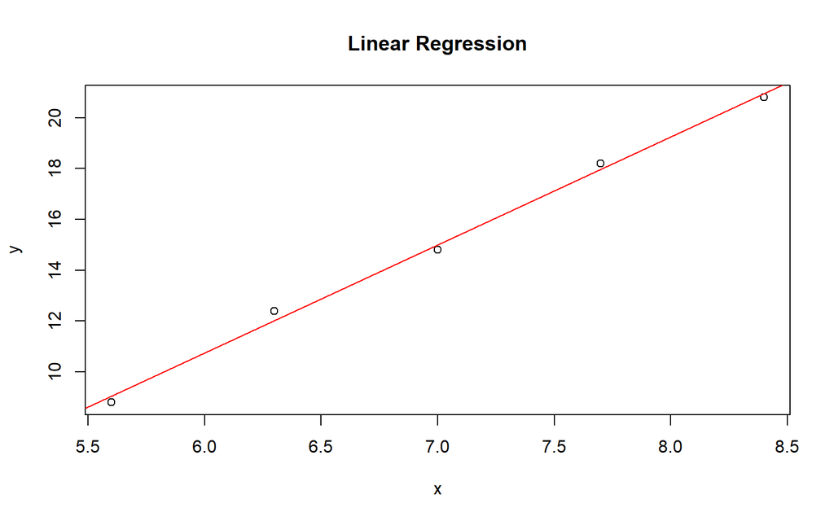

```r
plot(y~x, main = "Linear Regression")
abline(lm(y~x), col="red")
```

# 2 Question 2

Find all local maxima, local minima, and saddle points for the function given below. Write your answer(s) in the form (x,y,z). Separate multiple points with a comma.

$$f(x,y) = 24x -6xy^{2} -8y^{3}$$

## 2.1 Answer

Find partial derivative:

$f_{x} = 24 -6y^{2}$

$f_{y} = -12xy -24y^{2}$

$f_{xx} = 0$

$f_{xy} = -12y$

$f_{yy} = -12x -48y$

Find critical points:

$f_{x} = 24 -6y^{2} = 0 \Rightarrow y = [2,-2]$

$f_{y} = -12x(\pm 2) -24(\pm 2)^{2} = 0 \Rightarrow (x,y) = \{(-4,2),(4,-2)\}$

$f(-4,2) = -4\cdot24 -6\cdot(-4)\cdot4 -8\cdot8 = -64$

$f(4,-2) = 24\cdot4 -6\cdot4\cdot4 -8\cdot(-8) = 64$

Find discriminant:

$D(x,y) = f_{xx}f_{yy} -f^{2}_{xy} = 0 -(-12y)^{2} = -576 < 0$

Therefore, there are two saddle points $(4,-2,64)$ and $(-4,2,-64)$ with no maxima or minima.

# 3 Question 3

A grocery store sells two brands of a product, the “house” brand and a “name” brand. The manager estimates that if she sells the “house” brand for x dollars and the “name” brand for y dollars, she will be able to sell 81-21x+17y units of the “house” brand and 40+11x-23y units of the “name” brand.

Step 1. Find the revenue function R(x,y).

Step 2. What is the revenue if she sells the “house” brand for $2.30 and the “name” brand for $4.10?

## 3.1 Step 1

$R(x,y)$

$= (81-21x+17y) \cdot x +(40+11x-23y) \cdot y$

$= 81x -21x^{2} +17xy +40y +11xy -23y^{2}$

$= -21x^{2} +81x + 28xy + 40y - 23y^{2}$

## 3.2 Step 2

The revenus is $116.62 if she sells the “house” brand for $2.30 and the “name” brand for $4.10.

```r
81*2.3-21*2.3^2+28*2.3*4.1+40*4.1-23*4.1^2
```

```
## [1] 116.62
```

# 4 Question 4

A company has a plant in Los Angeles and a plant in Denver. The firm is committed to produce a total of **96** units of a product each week. The total weekly cost is given by $C(x,y) = \frac{1}{6}x^{2} +\frac{1}{6}y^{2} +7x +25y +700$ , where x is the number of units produced in Los Angeles and y is the number of units produced in Denver. How many units should be produced in each plant to minimize the total weekly cost?

## 4.1 Answer

$C(x,y) = \frac{1}{6}x^{2} +\frac{1}{6}y^{2} +7x +25y +700$

$C(x) = \frac{1}{6}x^{2} +\frac{1}{6}(96-x)^{2} +7x+25(96-x) +700$

$= \frac{1}{6}x^{2} +1536 -32x +\frac{1}{6}x^{2} +7x +2400 -25x +700$

$= \frac{1}{3}x^{2} -50x +4636$

Set $C' = \frac{dC}{dx} = \frac{2}{3}x -50 = 0$

$x = 75$

$y = 96 -75 = 21$

$C'' = \frac{d^{2}C}{dx^{2}} = \frac{2}{3} > 0$

$C(75,21) = \frac{1}{3}x^{2} -50x +4636 = 2761$

$\because$ $C''>0$, (75,21) is a relative minima.

$\therefore$ Los Angeles plant should produce 75 units and Denver plant should produce 21 units each week to minimize the total weekly cost at $2,761.

# 5 Quetsion 5

Evaluate the double integral on the given region.

$$\iint_{R}\left( e^{8x+3y} \right) dA; \; R:2\leq x\leq 4 \; and \; 2\leq y\leq 4$$
Write your answer in exact form without decimals.

## 5.1 Answer

$\iint_{R}\left( e^{8x+3y} \right) dA; \; R:2\leq x\leq 4 \; and \; 2\leq y\leq 4$

$= \int_{y=2}^{y=4}\int_{x=2}^{x=4} \left( e^{8x+3y} \right) dxdy$

$= \int_{2}^{4} e^{8x} dx \cdot \int_{2}^{4} e^{3y} dy$

$= \left[ \frac{e^{8x}}{8} \right]_{2}^{4} \cdot \left[ \frac{e^{3y}}{3} \right]_{2}^{4}$

$= \left( \frac{e^{32}-e^{16}}{8} \right) \left( \frac{e^{12}-e^{6}}{3} \right)$

$= \frac{e^{44}-e^{38}-e^{28}+e^{22}}{24}$